# **Adrian Pineda Sanchez**

# **Fecha de entrega: 26/08/2024**

# **Momento de Retroalimentación: Módulo 2 Uso de framework o biblioteca de aprendizaje máquina para la implementación de una solución. (Portafolio Implementación)**

## **Requerimientos**

- Selecciona cualquiera de los Challenge vistos en clase y programa un algoritmo que permita resolver el problema. Dicho algoritmo debe ser uno de los algoritmos vistos en el módulo (o que tu profesor de módulo autorice) haciendo uso de Scikit-learn.
- Divide el set de datos del problema en dos subconjuntos, uno para entrenamiento y otro para prueba.
- Entrena tu modelo sobre el primer subconjunto, y por un mínimo de 100 iteraciones. Selecciona valores para la tasa de aprendizaje y para los parámetros iniciales, según tu criterio.
- Prueba tu implementación. Para ello, utiliza el modelo entrenado para hacer predecir las salidas del subconjunto de prueba, y compara contra los datos reales en una gráfica.
- Calcula una métrica acorde a tu modelo, tanto para el subconjunto de entrenamiento, como para el subconjunto de prueba. Por ejemplo, si implementaste un algoritmo de regresión debes calcular el error cuadrático medio; si fue uno de clasificación, debes reportar las matrices de confusión y el f1-score.
- Entrega dos archivos: . El primero debe ser un Jupyter Notebook con todo el desarrollo (código comentado). El segundo debe ser un PDF del Jupyter Notebook. Para esto último, utiliza el comando nbconvert --to html para exportar el notebook a HTML y poder guardar el PDF más fácilmente (https://github.com/jupyter/nbconvert). Ten en cuenta que debes cargar tu directorio de Drive y dar la ruta al archivo, por lo que el comando completo sería: !jupyter nbconvert --to html /content/drive/MyDrive/ColabNotebooks/archivo.ipynb

```python
import pandas as pd
from sklearn.model_selection import train_test_split
from sklearn.linear_model import LogisticRegression
from sklearn.metrics import confusion_matrix, classification_report, f1_score
import matplotlib.pyplot as plt
import seaborn as sns
import pandas as pd
from sklearn.metrics import classification_report, confusion_matrix
import matplotlib.pyplot as plt
from sklearn.metrics import classification_report, confusion_matrix, f1_score
from sklearn.linear_model import LogisticRegression
from sklearn.model_selection import train_test_split
from sklearn.model_selection import GridSearchCV
```

# **1. Importacion Dataframe y transformacion de datos**

```python
# Specify the names in an list
names_wine = ["Class", "Alcohol", "Malic acid", "Ash", "Alcalinity of ash", "Magnesium", "Total phenols", "Flavanoids",
         "Nonflavanoid phenols", "Proanthocyanins", "Color intensity", "Hue", "OD280/OD315 of diluted wines",
         "Proline"]
# Open the file and create the data frame

df_wine = pd.read_csv("https://raw.githubusercontent.com/AdrianPinedaSanchez/ModuloSoftware/main/wine.data",names = names_wine)
data = df_wine
data
```

|  | Class | Alcohol | Malic acid | Ash | Alcalinity of ash | Magnesium | Total phenols | Flavanoids | Nonflavanoid phenols | Proanthocyanins | Color intensity | Hue | OD280/OD315 of diluted wines | Proline |
| --- | --- | --- | --- | --- | --- | --- | --- | --- | --- | --- | --- | --- | --- | --- |
| 0 | 1 | 14.23 | 1.71 | 2.43 | 15.6 | 127 | 2.80 | 3.06 | 0.28 | 2.29 | 5.64 | 1.04 | 3.92 | 1065 |
| 1 | 1 | 13.20 | 1.78 | 2.14 | 11.2 | 100 | 2.65 | 2.76 | 0.26 | 1.28 | 4.38 | 1.05 | 3.40 | 1050 |
| 2 | 1 | 13.16 | 2.36 | 2.67 | 18.6 | 101 | 2.80 | 3.24 | 0.30 | 2.81 | 5.68 | 1.03 | 3.17 | 1185 |
| 3 | 1 | 14.37 | 1.95 | 2.50 | 16.8 | 113 | 3.85 | 3.49 | 0.24 | 2.18 | 7.80 | 0.86 | 3.45 | 1480 |
| 4 | 1 | 13.24 | 2.59 | 2.87 | 21.0 | 118 | 2.80 | 2.69 | 0.39 | 1.82 | 4.32 | 1.04 | 2.93 | 735 |
| ... | ... | ... | ... | ... | ... | ... | ... | ... | ... | ... | ... | ... | ... | ... |
| 173 | 3 | 13.71 | 5.65 | 2.45 | 20.5 | 95 | 1.68 | 0.61 | 0.52 | 1.06 | 7.70 | 0.64 | 1.74 | 740 |
| 174 | 3 | 13.40 | 3.91 | 2.48 | 23.0 | 102 | 1.80 | 0.75 | 0.43 | 1.41 | 7.30 | 0.70 | 1.56 | 750 |
| 175 | 3 | 13.27 | 4.28 | 2.26 | 20.0 | 120 | 1.59 | 0.69 | 0.43 | 1.35 | 10.20 | 0.59 | 1.56 | 835 |
| 176 | 3 | 13.17 | 2.59 | 2.37 | 20.0 | 120 | 1.65 | 0.68 | 0.53 | 1.46 | 9.30 | 0.60 | 1.62 | 840 |
| 177 | 3 | 14.13 | 4.10 | 2.74 | 24.5 | 96 | 2.05 | 0.76 | 0.56 | 1.35 | 9.20 | 0.61 | 1.60 | 560 |

178 rows × 14 columns

# **2. Division Datos Entrenamiento y prueba (70% train y 30% test)**

```python
# Separar en características y variable objetivo
X = data.drop('Class', axis=1)  # 'Class' es la variable objetivo
y = data['Class']  # Variable objetivo
```

```python
# Dividir en conjunto de entrenamiento y prueba
X_train, X_test, y_train, y_test = train_test_split(X, y, test_size=0.3, random_state=42)
```

## **Justificacion para escoger un learning rate por medio de un grid search**

Modificar el parámetro C en un modelo de LogisticRegression es una estrategia efectiva para ajustar el balance entre la regularización y el ajuste del modelo.

En LogisticRegression, no es posible modificar directamente un learning rate como se haría en otros modelos, por lo que la regularización se ajusta mediante el parámetro C. Este parámetro controla la cantidad de regularización aplicada, lo que permite gestionar el equilibrio entre el sobreajuste y la subajuste.

- Valores altos de C: Reducen la regularización, permitiendo que el modelo se ajuste más a los datos de entrenamiento.
- Valores bajos de C: Incrementan la regularización, ayudando a que el modelo generalice mejor a datos no vistos.

Dado que LogisticRegression no permite un ajuste directo de la tasa de aprendizaje, ajustar C es la forma efectiva de controlar cómo el modelo optimiza su ajuste a los datos.

```
Mejor valor de C encontrado: {'C': 100}
F1-Score - Mejor modelo: 0.6759259259259259
```

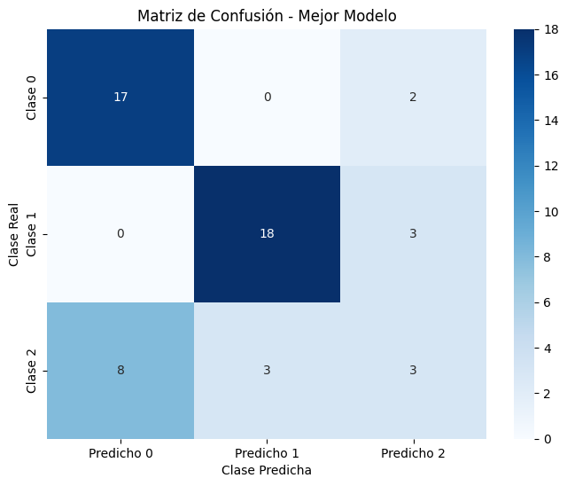

```
Reporte de Clasificación:
               precision    recall  f1-score    support
1              0.680000  0.894737  0.772727  19.000000
2              0.857143  0.857143  0.857143  21.000000
3              0.375000  0.214286  0.272727  14.000000
accuracy       0.703704  0.703704  0.703704   0.703704
macro avg      0.637381  0.655388  0.634199  54.000000
weighted avg   0.669815  0.703704  0.675926  54.000000
```

```python
from sklearn.linear_model import LogisticRegression
from sklearn.model_selection import GridSearchCV
from sklearn.metrics import confusion_matrix, classification_report, f1_score
import seaborn as sns
import matplotlib.pyplot as plt
import pandas as pd

# Escenario 1: Usar la característica relevante ('Alcohol')
X_train_relevant = X_train[['Alcohol']]
X_test_relevant = X_test[['Alcohol']]

# Definir el modelo de Logistic Regression
model_relevant = LogisticRegression(max_iter=1000)

# Definir los parámetros para la búsqueda del mejor valor de C
param_grid = {
    'C': [0.001, 0.01, 0.1, 1, 10, 100, 1000]  # Diferentes niveles de regularización
}

# Configurar el GridSearchCV para buscar el mejor C
grid_search = GridSearchCV(estimator=model_relevant, param_grid=param_grid, cv=5, n_jobs=-1, scoring='f1_macro')

# Entrenar el modelo con GridSearchCV
grid_search.fit(X_train_relevant, y_train)

# Mejor combinación de parámetros encontrada
best_params = grid_search.best_params_
print("Mejor valor de C encontrado:", best_params)

# Usar el mejor modelo para predecir
best_model = grid_search.best_estimator_
y_pred_relevant = best_model.predict(X_test_relevant)

# Calcular el F1-Score
f1_relevant = f1_score(y_test, y_pred_relevant, average='weighted')
print(f"F1-Score - Mejor modelo: {f1_relevant}")

# Generar la matriz de confusión
conf_matrix = confusion_matrix(y_test, y_pred_relevant)

# Crear un DataFrame para la matriz de confusión
df_cm = pd.DataFrame(conf_matrix, index=['Clase 0', 'Clase 1', 'Clase 2'], columns=['Predicho 0', 'Predicho 1', 'Predicho 2'])

# Graficar la matriz de confusión
plt.figure(figsize=(8, 6))
sns.heatmap(df_cm, annot=True, cmap='Blues', fmt='g')
plt.title('Matriz de Confusión - Mejor Modelo')
plt.ylabel('Clase Real')
plt.xlabel('Clase Predicha')
plt.show()

# Generar el reporte de clasificación
class_report = classification_report(y_test, y_pred_relevant, output_dict=True)

# Convertir el reporte de clasificación a un DataFrame
df_class_report = pd.DataFrame(class_report).transpose()
print("Reporte de Clasificación:\n", df_class_report)
```

## **Escenario 1: Usando una característica que usted crea es muy relevante**

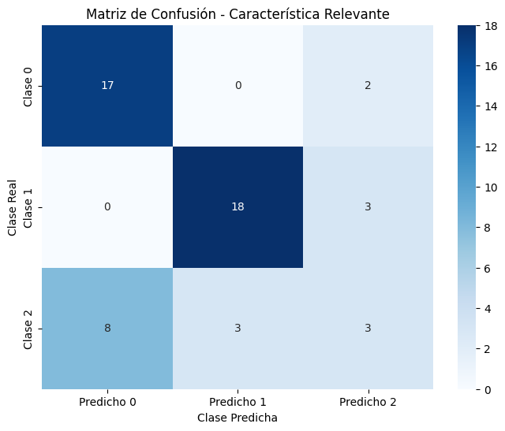

```python
# Escenario 1: Usar la característica relevante ('Alcohol')
X_train_relevant = X_train[['Alcohol']]
X_test_relevant = X_test[['Alcohol']]

# Valor de C previamente optimizado (C = 100)
optimal_C = 100

# Definir el modelo de Logistic Regression con el C optimizado
model_relevant = LogisticRegression(C=optimal_C, max_iter=1000)

# Entrenar el modelo
model_relevant.fit(X_train_relevant, y_train)

# Predecir los resultados
y_pred_relevant = model_relevant.predict(X_test_relevant)

# Generar la matriz de confusión
conf_matrix = confusion_matrix(y_test, y_pred_relevant)

# Crear un DataFrame para la matriz de confusión
df_cm = pd.DataFrame(conf_matrix, index=['Clase 0', 'Clase 1', 'Clase 2'], columns=['Predicho 0', 'Predicho 1', 'Predicho 2'])

# Graficar la matriz de confusión
plt.figure(figsize=(8, 6))
sns.heatmap(df_cm, annot=True, cmap='Blues', fmt='g')
plt.title('Matriz de Confusión - Característica Relevante')
plt.ylabel('Clase Real')
plt.xlabel('Clase Predicha')
plt.show()

# Generar el reporte de clasificación
class_report = classification_report(y_test, y_pred_relevant, output_dict=True)

# Convertir el reporte de clasificación a un DataFrame
df_class_report = pd.DataFrame(class_report).transpose()
```

```python
# Mostrar el DataFrame del reporte de clasificación
df_class_report
```

|  | precision | recall | f1-score | support |
| --- | --- | --- | --- | --- |
| 1 | 0.680000 | 0.894737 | 0.772727 | 19.000000 |
| 2 | 0.857143 | 0.857143 | 0.857143 | 21.000000 |
| 3 | 0.375000 | 0.214286 | 0.272727 | 14.000000 |
| accuracy | 0.703704 | 0.703704 | 0.703704 | 0.703704 |
| macro avg | 0.637381 | 0.655388 | 0.634199 | 54.000000 |
| weighted avg | 0.669815 | 0.703704 | 0.675926 | 54.000000 |

```python
# Calcular el F1-Score
f1_relevant = f1_score(y_test, y_pred_relevant, average='weighted')
print(f"F1-Score - Característica relevante: {f1_relevant}")
```

```
F1-Score - Característica relevante: 0.6759259259259259
```

```python
import matplotlib.pyplot as plt

# Imprimir algunos valores predichos en comparación con sus valores reales
comparison = pd.DataFrame({'Valor Real': y_test, 'Valor Predicho': y_pred_relevant})
print("Comparación de algunos valores reales vs predichos:")
comparison.head(10)
```

```
Comparación de algunos valores reales vs predichos:
```

|  | Valor Real | Valor Predicho |
| --- | --- | --- |
| 19 | 1 | 1 |
| 45 | 1 | 1 |
| 140 | 3 | 3 |
| 30 | 1 | 1 |
| 67 | 2 | 2 |
| 16 | 1 | 1 |
| 119 | 2 | 2 |
| 174 | 3 | 1 |
| 109 | 2 | 2 |
| 141 | 3 | 1 |

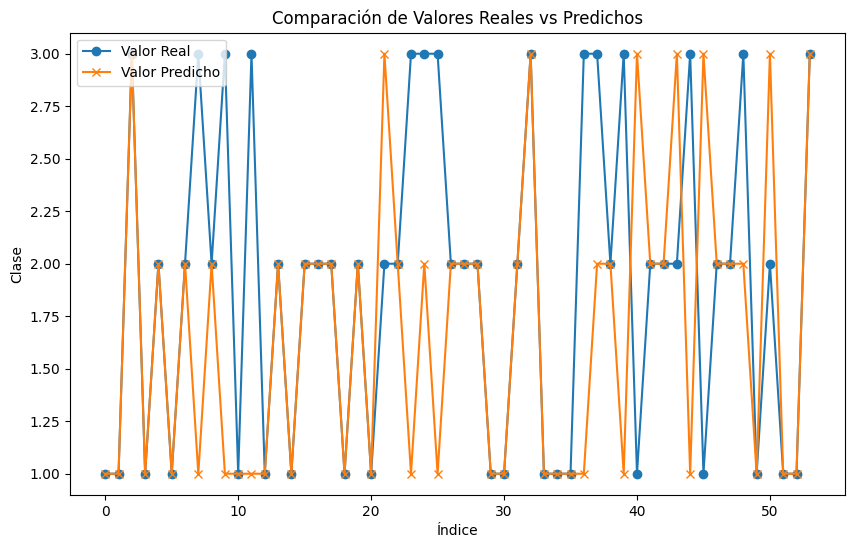

```python
# Graficar los valores reales vs predichos
plt.figure(figsize=(10, 6))
plt.plot(comparison['Valor Real'].values, label='Valor Real', marker='o')
plt.plot(comparison['Valor Predicho'].values, label='Valor Predicho', marker='x')
plt.title('Comparación de Valores Reales vs Predichos')
plt.xlabel('Índice')
plt.ylabel('Clase')
plt.legend()
plt.show()
```

## **Escenario 2: Usando una característica que considere como no relevante**

```
F1-Score - Característica no relevante con C = 100: 0.4957498482088646
```

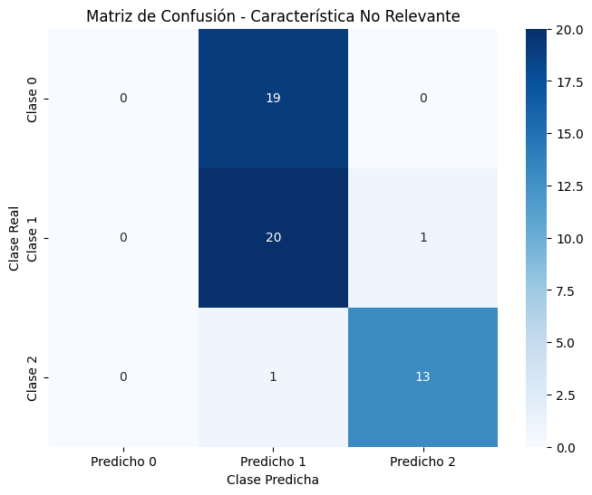

```python
# Escenario 2: Usar la característica no relevante ('Hue')
X_train_irrelevant = X_train[['Hue']]
X_test_irrelevant = X_test[['Hue']]

# Valor de C previamente optimizado (C = 100)
optimal_C = 100

# Definir el modelo de Logistic Regression con el C optimizado
model_irrelevant = LogisticRegression(C=optimal_C, max_iter=1000)

# Entrenar el modelo
model_irrelevant.fit(X_train_irrelevant, y_train)

# Predecir los resultados
y_pred_irrelevant = model_irrelevant.predict(X_test_irrelevant)

# Calcular el F1-Score
f1_irrelevant = f1_score(y_test, y_pred_irrelevant, average='weighted')
print(f"F1-Score - Característica no relevante con C = {optimal_C}: {f1_irrelevant}")

# Generar la matriz de confusión
conf_matrix = confusion_matrix(y_test, y_pred_irrelevant)

# Crear un DataFrame para la matriz de confusión
df_cm = pd.DataFrame(conf_matrix, index=['Clase 0', 'Clase 1', 'Clase 2'], columns=['Predicho 0', 'Predicho 1', 'Predicho 2'])

# Graficar la matriz de confusión
plt.figure(figsize=(8, 6))
sns.heatmap(df_cm, annot=True, cmap='Blues', fmt='g')
plt.title('Matriz de Confusión - Característica No Relevante')
plt.ylabel('Clase Real')
plt.xlabel('Clase Predicha')
plt.show()

# Generar el reporte de clasificación
class_report = classification_report(y_test, y_pred_irrelevant, output_dict=True)

# Convertir el reporte de clasificación a un DataFrame
df_class_report2 = pd.DataFrame(class_report).transpose()
```

```python
# Mostrar el DataFrame del reporte de clasificación
df_class_report2
```

|  | precision | recall | f1-score | support |
| --- | --- | --- | --- | --- |
| 1 | 0.000000 | 0.000000 | 0.000000 | 19.000000 |
| 2 | 0.500000 | 0.952381 | 0.655738 | 21.000000 |
| 3 | 0.928571 | 0.928571 | 0.928571 | 14.000000 |
| accuracy | 0.611111 | 0.611111 | 0.611111 | 0.611111 |
| macro avg | 0.476190 | 0.626984 | 0.528103 | 54.000000 |
| weighted avg | 0.435185 | 0.611111 | 0.495750 | 54.000000 |

```python
# Calcular el F1-Score
f1_irrelevant = f1_score(y_test, y_pred_irrelevant, average='weighted')
print(f"F1-Score - Característica no relevante: {f1_irrelevant}")
```

```
F1-Score - Característica no relevante: 0.4957498482088646
```

```python
# Imprimir algunos valores predichos en comparación con sus valores reales
comparison_irrelevant = pd.DataFrame({'Valor Real': y_test, 'Valor Predicho': y_pred_irrelevant})
print("Comparación de algunos valores reales vs predichos (Característica no relevante):")
comparison_irrelevant.head(10)  # Muestra las primeras 10 comparaciones
```

```
Comparación de algunos valores reales vs predichos (Característica no relevante):
```

|  | Valor Real | Valor Predicho |
| --- | --- | --- |
| 19 | 1 | 2 |
| 45 | 1 | 2 |
| 140 | 3 | 3 |
| 30 | 1 | 2 |
| 67 | 2 | 2 |
| 16 | 1 | 2 |
| 119 | 2 | 2 |
| 174 | 3 | 3 |
| 109 | 2 | 2 |
| 141 | 3 | 3 |

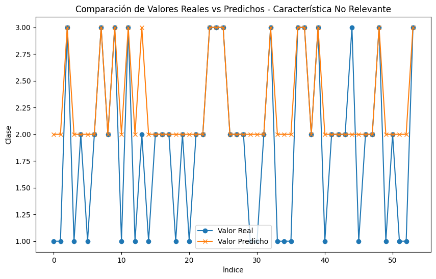

```python
# Graficar los valores reales vs predichos
plt.figure(figsize=(10, 6))
plt.plot(comparison_irrelevant['Valor Real'].values, label='Valor Real', marker='o')
plt.plot(comparison_irrelevant['Valor Predicho'].values, label='Valor Predicho', marker='x')
plt.title('Comparación de Valores Reales vs Predichos - Característica No Relevante')
plt.xlabel('Índice')
plt.ylabel('Clase')
plt.legend()
plt.show()
```

## **Escenario 3: Usando las dos características anteriores**

```
F1-Score - Ambas características con C = 1: 0.9065592692963967
```

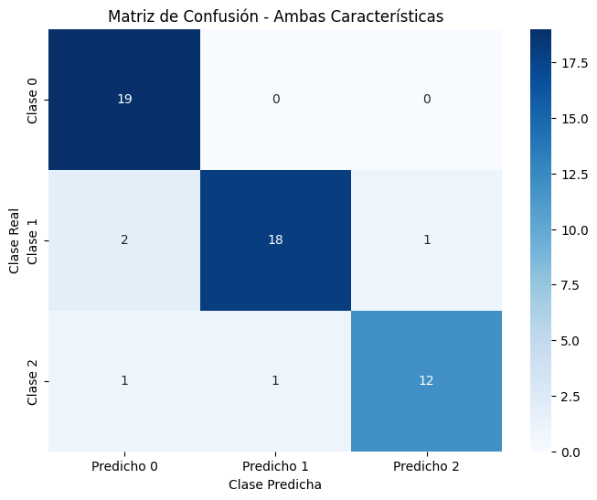

```python
# Escenario 3: Usar ambas características ('Alcohol' y 'Hue')
X_train_both = X_train[['Alcohol', 'Hue']]
X_test_both = X_test[['Alcohol', 'Hue']]

# Valor de C previamente optimizado (C = 100)
optimal_C = 1

# Definir el modelo de Logistic Regression con el C optimizado
model_both = LogisticRegression(C=optimal_C, max_iter=1000)

# Entrenar el modelo
model_both.fit(X_train_both, y_train)

# Predecir los resultados
y_pred_both = model_both.predict(X_test_both)

# Calcular el F1-Score
f1_both = f1_score(y_test, y_pred_both, average='weighted')
print(f"F1-Score - Ambas características con C = {optimal_C}: {f1_both}")

# Generar la matriz de confusión
conf_matrix = confusion_matrix(y_test, y_pred_both)

# Crear un DataFrame para la matriz de confusión
df_cm = pd.DataFrame(conf_matrix, index=['Clase 0', 'Clase 1', 'Clase 2'], columns=['Predicho 0', 'Predicho 1', 'Predicho 2'])

# Graficar la matriz de confusión
plt.figure(figsize=(8, 6))
sns.heatmap(df_cm, annot=True, cmap='Blues', fmt='g')
plt.title('Matriz de Confusión - Ambas Características')
plt.ylabel('Clase Real')
plt.xlabel('Clase Predicha')
plt.show()

# Generar el reporte de clasificación
class_report = classification_report(y_test, y_pred_both, output_dict=True)

# Convertir el reporte de clasificación a un DataFrame
df_class_report3 = pd.DataFrame(class_report).transpose()
```

Experimentando con estos hiperparametros no añadi el c =100 sino el c=1 en esta debido a que note una ligera mejora de 1.2% de F1-score al usarlo

```python
# Mostrar el DataFrame del reporte de clasificación
df_class_report3
```

|  | precision | recall | f1-score | support |
| --- | --- | --- | --- | --- |
| 1 | 0.863636 | 1.000000 | 0.926829 | 19.000000 |
| 2 | 0.947368 | 0.857143 | 0.900000 | 21.000000 |
| 3 | 0.923077 | 0.857143 | 0.888889 | 14.000000 |
| accuracy | 0.907407 | 0.907407 | 0.907407 | 0.907407 |
| macro avg | 0.911361 | 0.904762 | 0.905239 | 54.000000 |
| weighted avg | 0.911609 | 0.907407 | 0.906559 | 54.000000 |

```python
# Calcular el F1-Score
f1_both = f1_score(y_test, y_pred_both, average='weighted')
print(f"F1-Score - Ambas características: {f1_both}")
```

```
F1-Score - Ambas características: 0.9065592692963967
```

```python
# Imprimir algunos valores predichos en comparación con sus valores reales
comparison_both = pd.DataFrame({'Valor Real': y_test, 'Valor Predicho': y_pred_both})
print("Comparación de algunos valores reales vs predichos (Ambas características):")
comparison_both.head(10)  # Muestra las primeras 10 comparaciones
```

```
Comparación de algunos valores reales vs predichos (Ambas características):
```

|  | Valor Real | Valor Predicho |
| --- | --- | --- |
| 19 | 1 | 1 |
| 45 | 1 | 1 |
| 140 | 3 | 3 |
| 30 | 1 | 1 |
| 67 | 2 | 2 |
| 16 | 1 | 1 |
| 119 | 2 | 2 |
| 174 | 3 | 3 |
| 109 | 2 | 2 |
| 141 | 3 | 3 |

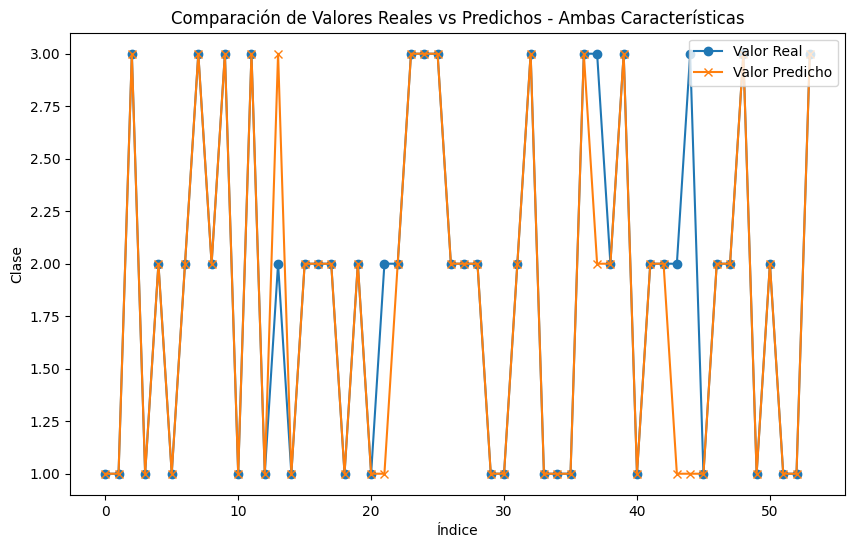

```python
# Graficar los valores reales vs predichos
plt.figure(figsize=(10, 6))
plt.plot(comparison_both['Valor Real'].values, label='Valor Real', marker='o')
plt.plot(comparison_both['Valor Predicho'].values, label='Valor Predicho', marker='x')
plt.title('Comparación de Valores Reales vs Predichos - Ambas Características')
plt.xlabel('Índice')
plt.ylabel('Clase')
plt.legend()
plt.show()
```

## **Escenario 4: Usar ambas características y sus cuadrados**

```
F1-Score - Características y términos cuadráticos con C = 100: 0.8885827561979324
```

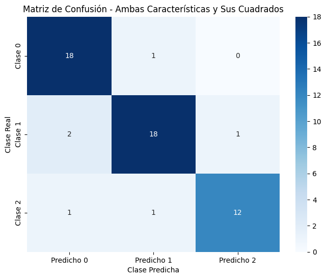

```python
# Añadir las columnas cuadráticas
X_train_squared = X_train_both.copy()
X_test_squared = X_test_both.copy()

X_train_squared['Alcohol_squared'] = X_train_squared['Alcohol']**2
X_train_squared['Hue_squared'] = X_train_squared['Hue']**2

X_test_squared['Alcohol_squared'] = X_test_squared['Alcohol']**2
X_test_squared['Hue_squared'] = X_test_squared['Hue']**2

# Valor de C previamente optimizado (C = 100)
optimal_C = 100

# Definir el modelo de Logistic Regression con el C optimizado
model_squared = LogisticRegression(C=optimal_C, max_iter=1000)

# Entrenar el modelo
model_squared.fit(X_train_squared, y_train)

# Predecir los resultados
y_pred_squared = model_squared.predict(X_test_squared)

# Calcular el F1-Score
f1_squared = f1_score(y_test, y_pred_squared, average='weighted')
print(f"F1-Score - Características y términos cuadráticos con C = {optimal_C}: {f1_squared}")

# Generar la matriz de confusión
conf_matrix = confusion_matrix(y_test, y_pred_squared)

# Crear un DataFrame para la matriz de confusión
df_cm = pd.DataFrame(conf_matrix, index=['Clase 0', 'Clase 1', 'Clase 2'], columns=['Predicho 0', 'Predicho 1', 'Predicho 2'])

# Graficar la matriz de confusión
plt.figure(figsize=(8, 6))
sns.heatmap(df_cm, annot=True, cmap='Blues', fmt='g')
plt.title('Matriz de Confusión - Ambas Características y Sus Cuadrados')
plt.ylabel('Clase Real')
plt.xlabel('Clase Predicha')
plt.show()

# Generar el reporte de clasificación
class_report = classification_report(y_test, y_pred_squared, output_dict=True)

# Convertir el reporte de clasificación a un DataFrame
df_class_report4 = pd.DataFrame(class_report).transpose()
```

```python
# Mostrar el DataFrame del reporte de clasificación
df_class_report4
```

|  | precision | recall | f1-score | support |
| --- | --- | --- | --- | --- |
| 1 | 0.857143 | 0.947368 | 0.900000 | 19.000000 |
| 2 | 0.900000 | 0.857143 | 0.878049 | 21.000000 |
| 3 | 0.923077 | 0.857143 | 0.888889 | 14.000000 |
| accuracy | 0.888889 | 0.888889 | 0.888889 | 0.888889 |
| macro avg | 0.893407 | 0.887218 | 0.888979 | 54.000000 |
| weighted avg | 0.890904 | 0.888889 | 0.888583 | 54.000000 |

```python
# Calcular el F1-Score
f1_squared = f1_score(y_test, y_pred_squared, average='weighted')
print(f"F1-Score - Ambas características y sus cuadrados: {f1_squared}")
```

```
F1-Score - Ambas características y sus cuadrados: 0.8885827561979324
```

```python
# Imprimir algunos valores predichos en comparación con sus valores reales
comparison_squared = pd.DataFrame({'Valor Real': y_test, 'Valor Predicho': y_pred_squared})
print("Comparación de algunos valores reales vs predichos (Características y términos cuadráticos):")
comparison_squared.head(10)  # Muestra las primeras 10 comparaciones
```

```
Comparación de algunos valores reales vs predichos (Características y términos cuadráticos):
```

|  | Valor Real | Valor Predicho |
| --- | --- | --- |
| 19 | 1 | 1 |
| 45 | 1 | 1 |
| 140 | 3 | 3 |
| 30 | 1 | 1 |
| 67 | 2 | 2 |
| 16 | 1 | 1 |
| 119 | 2 | 2 |
| 174 | 3 | 3 |
| 109 | 2 | 2 |
| 141 | 3 | 3 |

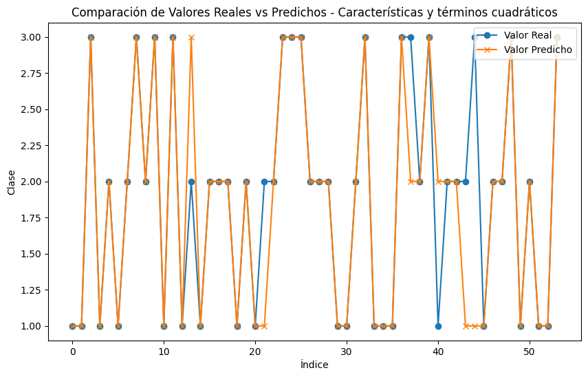

```python
# Graficar los valores reales vs predichos
plt.figure(figsize=(10, 6))
plt.plot(comparison_squared['Valor Real'].values, label='Valor Real', marker='o')
plt.plot(comparison_squared['Valor Predicho'].values, label='Valor Predicho', marker='x')
plt.title('Comparación de Valores Reales vs Predichos - Características y términos cuadráticos')
plt.xlabel('Índice')
plt.ylabel('Clase')
plt.legend()
plt.show()
```

# **Analisis de Resultados y conclusiones**

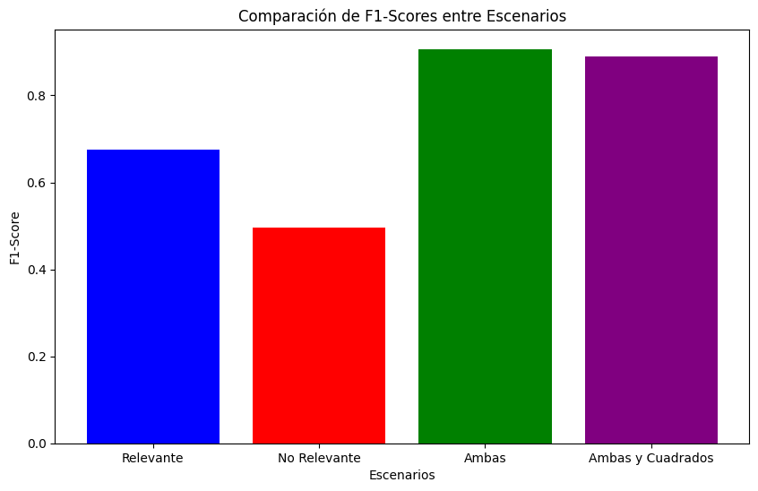

```python
# Comparar F1-Scores entre escenarios
labels = ['Relevante', 'No Relevante', 'Ambas', 'Ambas y Cuadrados']
f1_scores = [f1_relevant, f1_irrelevant, f1_both, f1_squared]

plt.figure(figsize=(10, 6))
plt.bar(labels, f1_scores, color=['blue', 'red', 'green', 'purple'])
plt.xlabel('Escenarios')
plt.ylabel('F1-Score')
plt.title('Comparación de F1-Scores entre Escenarios')
plt.show()
```

- Relevante (Alcohol): Este escenario utiliza solo la característica 'Alcohol', que se considera relevante. El F1-Score obtenido fue moderadamente alto, lo que sugiere que 'Alcohol' tiene una buena capacidad predictiva por sí sola.
- No Relevante (Hue): Este escenario utiliza solo la característica 'Hue', considerada no relevante. El F1-Score aquí es significativamente más bajo, lo que confirma que 'Hue' tiene menos valor predictivo en comparación con 'Alcohol'.
- Ambas (Alcohol y Hue): Al combinar ambas características, el F1-Score es el más alto de todos los escenarios. Esto indica que, aunque 'Hue' es menos relevante por sí sola, su combinación con 'Alcohol' mejora el rendimiento del modelo, posiblemente capturando una interacción entre las características que no es evidente de manera individual.
- Ambas y Cuadrados (Términos Cuadráticos): Este escenario añade términos cuadráticos a ambas características. El F1-Score es ligeramente menor que en el escenario "Ambas", lo que sugiere que los términos cuadráticos no aportan una mejora significativa al modelo. Esto podría deberse a que la relación entre las características y la clase objetivo es más lineal o que los términos cuadráticos no agregan suficiente información nueva.

## **Contexto problema**

Contexto del Problema y Recomendaciones Dado el contexto del problema, que implica maximizar la capacidad predictiva utilizando características de datos posiblemente relacionadas con la calidad o clase del vino, los resultados sugieren que:

El uso de ambas características (Alcohol y Hue) proporciona el mejor rendimiento predictivo. Esto sugiere que, a pesar de que 'Hue' es menos relevante por sí sola, su combinación con 'Alcohol' es sinérgica.

La adición de términos cuadráticos no mejora significativamente el modelo. Esto sugiere que no hay una relación no lineal fuerte entre las características y la clase objetivo, o que los términos cuadráticos añadidos no capturan una información valiosa adicional.

El enfoque futuro debería centrarse en la selección de características y posiblemente en la ingeniería de nuevas características que puedan capturar mejor las relaciones subyacentes en los datos, en lugar de añadir complejidad con términos cuadráticos que no aportan mejoras evidentes.

En resumen, la combinación de características relevantes es clave para mejorar el rendimiento del modelo, mientras que la adición de complejidad debe ser cuidadosamente considerada para evitar sobreajuste o redundancia en los datos.

```python
from google.colab import drive
drive.mount('/content/drive')
```

```python
!jupyter nbconvert --to html "/content/drive/MyDrive/Colab_Notebooks/ Framework_AdrianPineda_RegresionLogistica_Framework_Week02_Challenge2.ipynb"
```

```
[NbConvertApp] Converting notebook /content/drive/MyDrive/Colab_Notebooks/ Framework_AdrianPineda_RegresionLogistica_Framework_Week02_Challenge2.ipynb to html
[NbConvertApp] Writing 1480947 bytes to /content/drive/MyDrive/Colab_Notebooks/ Framework_AdrianPineda_RegresionLogistica_Framework_Week02_Challenge2.html
```